# 04: pivots_and_plots

Bryshal Moore & Hannah Houts

2023-07-20

If you were stuck on section 3 (or closed your session and are just coming back), goahead and tun this code to load in your data tables:

```r
library(tidyverse)
covariates <- read_tsv("data/FWS_covariates.txt")
abundances <- read_tsv("data/FWS_OTUs.txt")%>%
  rename(taxonomy = `...1`)
```

```
## ──────────────────────────────────────────────────────── Delimiter: "\t" chr
## (1): ...1 dbl (12): JPA_Jan, JPA_Feb, JPA_May, JPA_Jun, LOP_Jan, LOP_Feb,
## LOP_Jun, LOP...
```

## Pivots

Pivoting lets you reorganize the structure of your data by rearranging columns and rows. This can be crutial to getting data in the right format for plotting. (you might be familiar with this concept from excel, or `melt` in python)

You can pivot data wide or long. Wide data has more columns, and there is some type of data stored in the column names (e.g. sample, year, location). Long data has fewer columns, and the data that used to be part of the column names is now stored in a category column, with the values along side it.

The `pivot_wider()` function in R is used to transform data from a longer format to a wider format, allowing you to spread values across multiple columns based on a key-value pair. Conversely, the `pivot_longer()` function is used to transform data from a wider format to a longer format, where multiple columns are combined into key-value pairs, providing a more compact representation of the data.

let’s try this with our abundances table. recall the column names:

```r
names(abundances)
```

```
##  [1] "taxonomy" "JPA_Jan"  "JPA_Feb"  "JPA_May"  "JPA_Jun"  "LOP_Jan"
##  [7] "LOP_Feb"  "LOP_Jun"  "LOP_Jul"  "MBL_Jan"  "MBL_Feb"  "MBL_Jun"
## [13] "MBL_Aug"
```

Notice that many of the column names are sample ids. We can pivot the data longer, by creating a column called “sample”, and storing the count data in a column along side (“count”).

note: we are saving this as a new variable, to work with further in a bit.

```r
 abundances_long <- abundances %>%
  pivot_longer(
    !taxonomy, #pivot all the rows except taxonomy
    names_to = "sample", values_to = "count"
  )
abundances_long
```

```
## # A tibble: 4,644 × 3
##    taxonomy                                                         sample count
##    <chr>                                                            <chr>  <dbl>
##  1 Bacteria;Acidobacteria;Acidobacteria;Acidobacteriales;Acidobact… JPA_J…     0
##  2 Bacteria;Acidobacteria;Acidobacteria;Acidobacteriales;Acidobact… JPA_F…     0
##  3 Bacteria;Acidobacteria;Acidobacteria;Acidobacteriales;Acidobact… JPA_M…     0
##  4 Bacteria;Acidobacteria;Acidobacteria;Acidobacteriales;Acidobact… JPA_J…     0
##  5 Bacteria;Acidobacteria;Acidobacteria;Acidobacteriales;Acidobact… LOP_J…     0
##  6 Bacteria;Acidobacteria;Acidobacteria;Acidobacteriales;Acidobact… LOP_F…     0
##  7 Bacteria;Acidobacteria;Acidobacteria;Acidobacteriales;Acidobact… LOP_J…     0
##  8 Bacteria;Acidobacteria;Acidobacteria;Acidobacteriales;Acidobact… LOP_J…     0
##  9 Bacteria;Acidobacteria;Acidobacteria;Acidobacteriales;Acidobact… MBL_J…     0
## 10 Bacteria;Acidobacteria;Acidobacteria;Acidobacteriales;Acidobact… MBL_F…     3
## # ℹ 4,634 more rows
```

Now we want to take `abundance_long`, and pivot it wider *by taxonomy*, instead of by sample.

```r
abundances_wide_tax <- abundances_long %>%
  pivot_wider(
    names_from = taxonomy,
    values_from = count
    )
abundances_wide_tax
```

```
## # A tibble: 12 × 388
##    sample  Bacteria;Acidobacteri…¹ Bacteria;Acidobacter…² Bacteria;Acidobacter…³
##    <chr>                     <dbl>                  <dbl>                  <dbl>
##  1 JPA_Jan                       0                      0                      0
##  2 JPA_Feb                       0                      2                      5
##  3 JPA_May                       0                      0                      0
##  4 JPA_Jun                       0                      0                      0
##  5 LOP_Jan                       0                      0                      4
##  6 LOP_Feb                       0                      0                      0
##  7 LOP_Jun                       0                      0                      0
##  8 LOP_Jul                       0                      0                      0
##  9 MBL_Jan                       0                      0                      0
## 10 MBL_Feb                       3                      0                      4
## 11 MBL_Jun                       0                      0                      0
## 12 MBL_Aug                       0                      0                      6
## # ℹ abbreviated names:
## #   ¹`Bacteria;Acidobacteria;Acidobacteria;Acidobacteriales;Acidobacteriaceae;Edaphobacter`,
## #   ²`Bacteria;Acidobacteria;Acidobacteria;Acidobacteriales;Acidobacteriaceae;Solibacter`,
## #   ³`Bacteria;Acidobacteria;Acidobacteria;Acidobacteriales;Acidobacteriaceae;genus_NA`
## # ℹ 384 more variables:
## #   `Bacteria;Acidobacteria;Acidobacteria_Gp22;Unassigned;Unassigned;Gp22` <dbl>,
## #   `Bacteria;Acidobacteria;Holophagae;Holophagales;Holophagaceae;Geothrix` <dbl>, …
```

## Plotting Your Hard Work!

Lets extract something cool out of this new table! Its nice to end the day with an image.

You don’t need to deeply understand this code (we will cover more on Saturday morning), but feel free to ask questions, or poke/break/tinker as much as you like.

Note that we needed that `abundances_wide_tax` table to make this plot. Good thing we have tidyverse ;)

```r
if (!requireNamespace("vegan", quietly = TRUE)) {
     install.packages("vegan")
}
library(vegan)
```

```r
    # makes a table in the form of a matrix, where every value in the table is numeric
abund_matrix <- as.matrix(
                          abundances_wide_tax %>%
                          select(!sample) # eliminates the sample column, which is not numeric.
                          )

distances <- vegdist(abund_matrix, method = "euclidean") # calculates the distances between samples in 387 dimensions


pcoa_plotting_data <- cmdscale(distances, eig= TRUE, k=2) # reduces dimensions
                    # cmd stands for classical multidimensional scaling

pcoa_point_data <- as.data.frame(pcoa_plotting_data$points) # extracts plottable x,y coordinates from PCoA plot

pcoa_point_data$sample <- NA # add a new empty column
pcoa_point_data$sample <- abundances_wide_tax$sample  # fill that column with contents of sample column from the abundances_wide_tax table


covariates <- covariates %>%
  rename(sample=SampleName)

pcoa_w_metadata <- inner_join(pcoa_point_data, covariates, by = "sample") # merges the covariates table with the pcoa table


pcoa_w_metadata # take a peek at the final table, then we will plot!
```

```
##            V1         V2  sample         Location Month Season      Type
## 1  -5092.2208  -278.7448 JPA_Jan Jones-Palmer Ave   Jan Winter   Outfall
## 2   -323.3878  -262.7328 JPA_Feb Jones-Palmer Ave   Feb Winter   Outfall
## 3   2879.0448  1345.1309 JPA_May Jones-Palmer Ave   May Summer   Outfall
## 4   5257.1176 -5565.6374 JPA_Jun Jones-Palmer Ave   Jun Summer   Outfall
## 5   -968.3879   784.8636 LOP_Jan        Long Pond   Jan Winter Reservoir
## 6  -4381.5034  -200.7364 LOP_Feb        Long Pond   Feb Winter Reservoir
## 7   3900.9462  2014.2134 LOP_Jun        Long Pond   Jun Summer Reservoir
## 8   2939.9600  1273.9327 LOP_Jul        Long Pond   Jul Summer Reservoir
## 9  -1365.2333   397.0529 MBL_Jan              MBL   Jan Winter   Outfall
## 10 -7340.6834 -1203.4646 MBL_Feb              MBL   Feb Winter   Outfall
## 11  2424.0055  1007.3486 MBL_Jun              MBL   Jun Summer   Outfall
## 12  2070.3425   688.7740 MBL_Aug              MBL   Aug Summer   Outfall
```

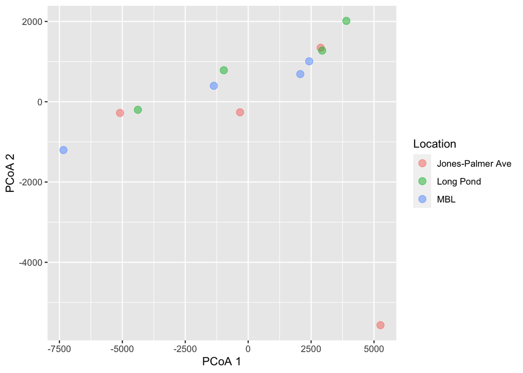

```r
#Plot by Location
ggplot(pcoa_w_metadata,
       aes(
         x=V1,
         y=V2,
         color = Location
           )
       ) +
  geom_point(size = 3, alpha = .5) +
  # geom_text_repel() +
  xlab("PCoA 1") +
  ylab("PCoA 2")
```

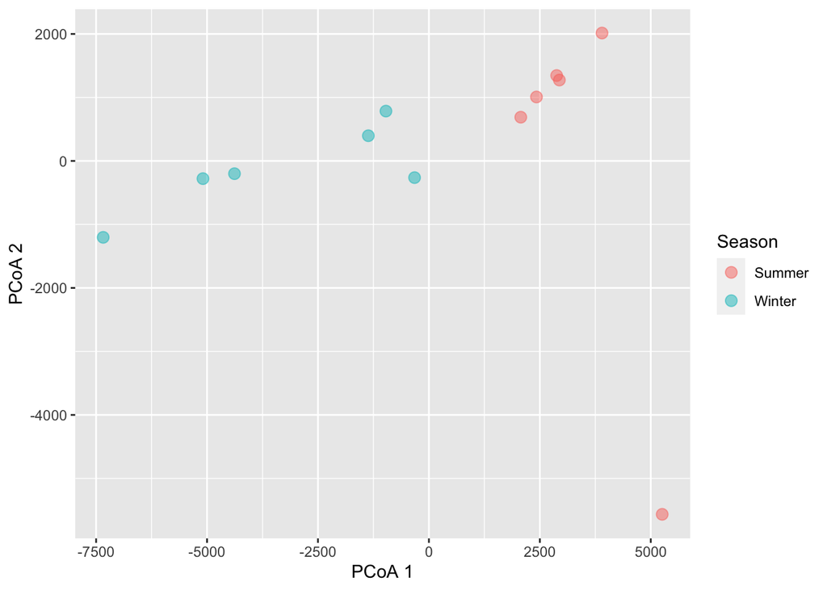

```r
#Plot by season
ggplot(pcoa_w_metadata,
       aes(
         x=V1,
         y=V2,
         color = Season
           )
       ) +
  geom_point(size = 3, alpha = .5) +
  # geom_text_repel() +
  xlab("PCoA 1") +
  ylab("PCoA 2")
```

Great work!